# STAT 440: Homework 04

### Spring 2021, D. Unger

### Due: Monday, April 5 by 11:00 PM CT

# NetId: vvgupta2

All students (both undergraduate and graduate) are expected to complete **Exercises 1-10**.

### Exercise 1

(Arranging data) Based on the image, which of the following best describes how the data is arranged?

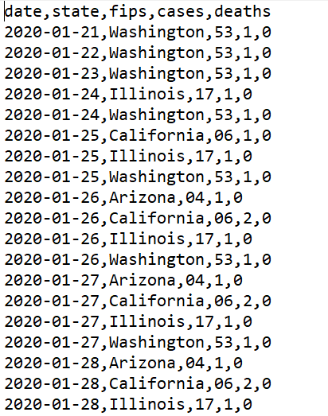

- sorted by Fips then Date

**- sorted by Date then State**

- sorted by Date then State then Cases
- sorted by Date only

### Exercise 2

(Accessing and importing data, Exploring file formats and different types of data) Import the 1996 NBA Season Data (existing as three separate data sets) using one programming language software and the data URLs [stint1](https://uofi.box.com/shared/static/vytgfoo28wf9q4tct61j3sk02pwpsjsn.json), [stint2](https://uofi.box.com/shared/static/3zu8hqubabw8hxqt14qwjpeginf2orgo.json), and [stint3](https://uofi.box.com/shared/static/cfqaufkt73f8iej2v4pf2bsc4b6ok955.json). Now, print the first 5 observations of each separate data set (15 observations total).

The dataset (three .json files) contains a total of 441 unique observations and 25 columns. The observations are professional basketball players in the National Basketball Association (NBA) and their season statistics for the 1996-1997 season. A stint is the duration of time someone worked for a particular employer. In this basketball data, a stint is a number representing the time a player was with a particular team. Some players are traded during the season, which means they would have more than 1 stint. A player’s basketball statistics start over for each stint they have in a season. There are 441 unique playerIDs across all stints. The original source is the NBA and Sports Reference.

```r
#install.packages("htm2txt")
#tinytex::reinstall_tinytex()
library(tidyverse)
library(plyr)
library(dplyr)
library(data.table)
library(htm2txt)
stint1 = jsonlite::fromJSON("https://uofi.box.com/shared/static/vytgfoo28wf9q4tct61j3sk02pwpsjsn.json")
stint2 = jsonlite::fromJSON("https://uofi.box.com/shared/static/3zu8hqubabw8hxqt14qwjpeginf2orgo.json")
stint3 = jsonlite::fromJSON("https://uofi.box.com/shared/static/cfqaufkt73f8iej2v4pf2bsc4b6ok955.json")
head (stint1, n=5)
```

```
##                Player  PlayerID Pos Age  Tm  G GS   MP  FG  FGA ThreeP ThreePA
## 1  Mahmoud Abdul-Rauf abdulma02  PG  27 SAC 75 51 2131 411  924     94     246
## 2 Shareef Abdur-Rahim abdursh01  PF  20 VAN 80 71 2802 550 1214      7      27
## 3      Rafael Addison addisra01  SF  32 CHH 41  3  355  49  122      8      20
## 4      Cory Alexander alexaco01  PG  23 SAS 80  6 1454 194  490     94     252
## 5        Jerome Allen allenje01  SG  24 IND 51  1  692  57  147     23      59
##   TwoP TwoPA  FT FTA ORB DRB AST STL BLK TOV  PF  PTS stint
## 1  317   678 115 136  16 106 189  56   6 119 174 1031     1
## 2  543  1187 387 519 216 339 175  79  79 225 199 1494     1
## 3   41   102  22  28  19  26  34   8   3  17  52  128     1
## 4  100   238  95 129  29  94 254  82  16 146 148  577     1
## 5   34    88  27  47  13  52 109  27   0  56  67  164     1
```

```r
head (stint2, n=5)
```

```
##          Player  PlayerID Pos Age  Tm  G GS  MP FG FGA ThreeP ThreePA TwoP
## 1  Jerome Allen allenje01  SG  24 DEN 25  0 251 21  74      7      34   14
## 2 Vincent Askew askewvi01  SG  30 IND 41  0 822 79 183      7      24   72
## 3 Stacey Augmon augmost01  SG  28 POR 40  7 650 74 143      0       0   74
## 4 Elmer Bennett benneel01  PG  26 DEN  5  0  59  4  13      2       6    2
## 5 Melvin Booker bookeme01  PG  24 GSW 16  4 409 44 101     11      35   33
##   TwoPA FT FTA ORB DRB AST STL BLK TOV  PF PTS stint
## 1    40 15  25  12  21  43   4   4  13  17  64     2
## 2   159 68  86  25  73  90  17   6  42 122 233     2
## 3   143 41  56  33  56  41  32   7  37  58 189     2
## 4     7  2   4   0   3   7   2   0  10   6  12     2
## 5    66 18  20   7  21  50   3   2  20  28 117     2
```

```r
head (stint3, n=5)
```

```
##            Player  PlayerID Pos Age  Tm  G GS  MP  FG FGA ThreeP ThreePA TwoP
## 1   Vincent Askew askewvi01  SG  30 DEN  1  0   9   2   3      0       0    2
## 2     Sam Cassell cassesa01  PG  27 NJN 23 22 777 167 377     47     120  120
## 3  Darrin Hancock hancoda01  SF  25 SAS  1  0   8   1   2      0       0    1
## 4      Joe Kleine kleinjo01   C  35 NJN 28  0 453  35  82      1       2   34
## 5 Rumeal Robinson robinru01  PG  30 POR 27  0 295  33  82      9      23   24
##   TwoPA FT FTA ORB DRB AST STL BLK TOV PF PTS stint
## 1     3  2   2   0   0   0   0   0   4  0   6     3
## 2   257 64  77  21  61 149  37   7  67 86 445     3
## 3     2  2   2   0   0   1   0   0   0  2   4     3
## 4    80 13  18  39  75  23   8  12  21 57  84     3
## 5    59 20  23   3  27  52  18   0  27 40  95     3
```

### Exercise 3

(Assigning objects, Subsetting with numbers, Arranging data, Subsetting with characters (i.e. regular expression and string manipulation), Looping and conditional execution, Apply family of functions, Validating data, Cleaning data, Vectorization, Combining data)

Beginning with the three NBA data sets in **Exercise 2** and the information in the link https://uofi.box.com/shared/static/enzji09o5iz1butp3763mcnbaeoyimaa.pdf, do the following:

1. combine the three data sets into a single data set named **nba1996_1**
2. keep the unique players such that those with latest stints are present, thus removing a player’s earlier stints
3. create a new variable called “ato” that represents the assists to turnovers ratio (assists divided by turnovers)
4. create a new variable called “ptm” that represents the points to minutes played ratio (points divided by minutes played)
5. create a new variable called “threeptpercentage” that represents three-point shots made out of three-point attempts multiplied by 100

Finally, print the first 5 observations of **nba1996_1** such that the data is sorted by ptm in descending order then player ID alphabetically and showing the following columns only: player name, player ID, position, age, ptm.

```r
nba1996_1 = rbind(stint1, stint2, stint3)
nba1996_1 = nba1996_1 %>%
  group_by(Player)%>%
  slice(which.max(stint))%>%
  mutate( ato = AST/TOV) %>%
  mutate( ptm = PTS/MP) %>%
  mutate( threeptpercentage = (ThreeP/ThreePA)*100) %>%
  arrange(desc(ptm), PlayerID) %>%
  select(Player, PlayerID, Pos, Age, ptm)
head(nba1996_1, 5)
```

```
## # A tibble: 5 x 5
## # Groups:   Player [5]
##   Player            PlayerID  Pos     Age   ptm
##   <chr>             <chr>     <chr> <int> <dbl>
## 1 Michael Jordan*   jordami01 SG       33 0.783
## 2 Karl Malone*      malonka01 PF       33 0.750
## 3 David Robinson*   robinda01 C        31 0.721
## 4 Shaquille O'Neal* onealsh01 C        24 0.688
## 5 Mitch Richmond*   richmmi01 SG       31 0.670
```

### Exercise 4

(Assigning objects, Subsetting with numbers, Arranging data, Subsetting with characters (i.e. regular expression and string manipulation), Looping and conditional execution, Apply family of functions, Validating data, Cleaning data, Vectorization, Combining data, Summarizing data) Beginning with the three NBA data sets in **Exercise 2** and the information in the link https://uofi.box.com/shared/static/enzji09o5iz1butp3763mcnbaeoyimaa.pdf, do all of the following:

1. remove the following variables: team id and stint
2. combine the three data sets into a single data set named **nba_1996_2**
3. keep the unique players such that all basketball statistics are totaled across all stints per player
4. create a new variable called “rebounds” that represents a combination of offensive rebounds and defensive rebounds
5. create a new variable called “efficiency” that represents the NBA’s efficiency rating using the formula: (points + rebounds + assists + steals + blocks - ((field goals attempted - field goals made) + (free throws attempted - free throws made) + turnovers)) / games played

Finally, print the first 5 observations of **nba1996_2** such that the data is sorted by rebounds in descending order then player ID alphabetically and showing the following columns only: player name, player ID, position, age, rebounds.

```r
#install.packages("plyr")
nba_1996_2 = rbind(stint1, stint2, stint3)
nba_1996_2 = nba_1996_2 %>%
  select(-c(`Tm`, `stint`)) %>%
  group_by(`PlayerID`, `Player`, `Pos`) %>%
  summarise_each(funs(sum))
something = nba_1996_2 %>%
  group_by(`PlayerID`) %>%
  filter(n()>1)
something = something %>%
  group_by(`PlayerID`) %>%
  mutate(Playerposition = paste(Pos, collapse = ",")) %>%
  group_by(Player, PlayerID, Playerposition) %>%
  mutate_if(is.numeric, sum) %>%
  mutate_if(is.character, toString) %>%
  summarise_all(first) %>%
  ungroup() %>%
  select(-c(Playerposition))
```

```
## `mutate_if()` ignored the following grouping variables:
## Columns `Player`, `PlayerID`, `Playerposition`
## `mutate_if()` ignored the following grouping variables:
## Columns `Player`, `PlayerID`, `Playerposition`
```

```r
nba_1996_2 = nba_1996_2 %>%
  group_by(`PlayerID`, `Player`) %>%
  filter(n()==1)
nba_1996_2 = rbind(nba_1996_2, something)
nba_1996_2 = nba_1996_2 %>%
  mutate(rebounds = ORB + DRB, efficiency = PTS + rebounds + AST + STL + BLK - ((FGA - FG) + (FTA - FT) + TOV) / G)

top5 = nba_1996_2 %>%
  arrange(desc(rebounds), PlayerID) %>%
  select(Player, PlayerID, Pos, Age, rebounds)

head(top5, 5)
```

```
## # A tibble: 5 x 5
## # Groups:   PlayerID, Player [5]
##   Player           PlayerID  Pos     Age rebounds
##   <chr>            <chr>     <chr> <int>    <int>
## 1 Dikembe Mutombo* mutomdi01 C        30      929
## 2 Ervin Johnson    johnser02 C        29      913
## 3 Dennis Rodman*   rodmade01 PF       35      883
## 4 Patrick Ewing*   ewingpa01 C        34      834
## 5 Anthony Mason    masonan01 PF       30      829
```

### Exercise 5

(Assigning objects, Subsetting with numbers, Arranging data, Subsetting with characters (i.e. regular expression and string manipulation), Looping and conditional execution, Apply family of functions, Vectorization) Which of the 15 most efficient players in the 1996-1997 season are currently in the NBA Hall of Fame? Use the **nba_1996_2** data set in **Exercise 4**, information in the link https://www.nba.com/history/hall-of-fame-inductees, and a programming language applying data management concepts to answer the question.

*Make sure your result is sorted by efficiency descending order then player ID alphabetically and only shows the variables referenced in the question.*

```r
hall_of_fame = gettxt('https://www.nba.com/history/hall-of-fame-inductees')
top15 = nba_1996_2 %>%
  ungroup() %>%
  slice_max(efficiency, n = 15) %>%
  mutate(HOF = sapply(Player, grepl, hall_of_fame)) %>%
  select(c(Player, PlayerID, efficiency, HOF)) %>%
  arrange(desc(efficiency), Player)
top15
```

```
## # A tibble: 15 x 4
##    Player           PlayerID  efficiency HOF
##    <chr>            <chr>          <dbl> <lgl>
##  1 Karl Malone*     malonka01      3573. TRUE
##  2 Michael Jordan*  jordami01      3434. TRUE
##  3 Grant Hill*      hillgr01       3193. TRUE
##  4 Hakeem Olajuwon* olajuha01      3038. TRUE
##  5 Patrick Ewing*   ewingpa01      2985. TRUE
##  6 Latrell Sprewell sprewla01      2973. FALSE
##  7 Gary Payton*     paytoga01      2943. TRUE
##  8 Tom Gugliotta    guglito01      2914. FALSE
##  9 Mitch Richmond*  richmmi01      2880. TRUE
## 10 Scottie Pippen*  pippesc01      2841. TRUE
## 11 Vin Baker        bakervi01      2832. FALSE
## 12 Allen Iverson*   iversal01      2829. TRUE
## 13 Kendall Gill     gillke01       2800. FALSE
## 14 Damon Stoudamire stoudda01      2794. FALSE
## 15 Chris Webber     webbech01      2765. FALSE
```

**Among the 15 most efficient players in the 1996-1997 season, Karl Malone, Michael Jordan, Grant Hill, Hakeem Olajuwon, Patrick Ewing, Gary Payton, Mitch Richmond, Scottie Pippen, and Allen Iverson are currently in the NBA Hall of Fame.**

### Exercise 6

(Assigning objects, Subsetting with numbers, Arranging data, Subsetting with characters (i.e. regular expression and string manipulation), Looping and conditional execution, Apply family of functions, Vectorization) Beginning with the three NBA data sets in **Exercise 2** and the information in the link https://uofi.box.com/shared/static/enzji09o5iz1butp3763mcnbaeoyimaa.pdf, do all of the following:

1. combine the three data sets into a single data set named **nba_1996_3**
2. each player should be represented exactly once
3. create a new variable called “total.stints” that represents the total number of teams each player played for that season
4. create a new variable called “longest” that represents the team that each player played the most games with; if there is a tie for most games, keep the earliest team he played for.

Finally, print the first 10 observations of **nba1996_3** such that the data is sorted by total.stints in descending order then player ID alphabetically and showing the following columns only: player name, player ID, position, total.stints, longest.

```r
nba_1996_3 = rbind(stint1, stint2, stint3)
nba_1996_3 = nba_1996_3 %>%
  ungroup() %>%
  group_by(`PlayerID`, `Player`,`Tm`, `Pos`) %>%
  summarise_each(funs(sum))
ayx = nba_1996_3 %>%
  group_by(`PlayerID`) %>%
  filter(n()>1) %>%
  mutate(longest = Tm[which.max(G)]) %>%
  group_by(Player, PlayerID, longest) %>%
  mutate_if(is.numeric, sum) %>%
  mutate_if(is.character, toString) %>%
  summarise_all(first) %>%
  ungroup()
```

```
## `mutate_if()` ignored the following grouping variables:
## Columns `Player`, `PlayerID`, `longest`
## `mutate_if()` ignored the following grouping variables:
## Columns `Player`, `PlayerID`, `longest`
```

```r
nba_1996_3 = nba_1996_3 %>%
  group_by(`PlayerID`, `Player`) %>%
  filter(n()==1) %>%
  mutate(longest = Tm)
nba_1996_3 = rbind(nba_1996_3, ayx)
nba_1996_3 = nba_1996_3 %>%
  mutate(total.stints = ifelse(stint == 6, 3, ifelse(stint == 3, 2, 1))) %>%
  arrange(desc(total.stints), PlayerID)
top10 = nba_1996_3 %>%
  select(c(Player, PlayerID, Pos, total.stints, longest))
head(top10, 10)
```

```
## # A tibble: 10 x 5
## # Groups:   PlayerID, Player [10]
##    Player          PlayerID  Pos        total.stints longest
##    <chr>           <chr>     <chr>             <dbl> <chr>
##  1 Vincent Askew   askewvi01 SG, SG, SG            3 GSW
##  2 Sam Cassell     cassesa01 PG, PG, PG            3 GSW
##  3 Darrin Hancock  hancoda01 SF, SF, SF            3 GSW
##  4 Joe Kleine      kleinjo01 C, C, C               3 GSW
##  5 Rumeal Robinson robinru01 PG, PG, PG            3 GSW
##  6 Donald Royal    royaldo01 SF, SF, SF            3 GSW
##  7 Kenny Smith     smithke01 PG, PG, PG            3 GSW
##  8 Jerome Allen    allenje01 SG, SG                2 GSW
##  9 Stacey Augmon   augmost01 SG, SG                2 GSW
## 10 Elmer Bennett   benneel01 PG, PG                2 GSW
```

### Exercise 7

(Accessing and importing data, Exploring file formats and different types of data) Import the subsets of the IRI Academic Data (existing as three separate data sets) using one programming language software and the data URLs [ads_demo_big](https://uofi.box.com/shared/static/buv7xuweoq51zw4obcf2netx4d16295h.csv), [trips_big](https://uofi.box.com/shared/static/wmsx1tvrrncryf0ue7ldp4szhizdb3gf.txt), [delivery_stores_big](https://uofi.box.com/shared/static/56bzob5ub1pu5im5fgm1125e4xocbwj2), and the information in the link https://uofi.box.com/shared/static/vmskkej4vt8vy2f17l4zrb9u7y66kpnm.pdf. Print the data description of each separate data set.

The data all represent sales information and customer demographics captured from select markets in the US in the year 2001. The ads_demo_big data (a .csv file) contain 13983 observations and 20 columns that inform on customer (“panelist”) demographics. Panelist ID is a unique identifier. The trips_big data (a .txt file) contain 730040 observations and 4 columns that inform on panelist shopping frequency and how much was spent. The delivery_stores_big data (a file with no extension) contain 1575 observations and 7 columns that inform on the market that the store is in and estimates how much that store sells annually.

```r
data_import_tool <- function(file_location, delimiter){
  library(tidyverse)
  if (delimiter==",")
    readr::read_csv(file_location)
  else if (delimiter=="comma")
    readr::read_csv(file_location)
  else if (delimiter==" ")
    readr::read_table2(file_location)
  else if (delimiter=="space")
    readr::read_table2(file_location)
  else if (delimiter=="tab")
    readr::read_tsv(file_location)
  else if (delimiter=="\t")
    readr::read_tsv(file_location)
  else if (delimiter==":")
    readr::read_delim(file_location, delim = ":")
  else if (delimiter=="colon")
    readr::read_delim(file_location, delim = ":")
}
ads_demo_big <- data_import_tool("https://uofi.box.com/shared/static/buv7xuweoq51zw4obcf2netx4d16295h.csv", ",")
trips_big <- data_import_tool("https://uofi.box.com/shared/static/wmsx1tvrrncryf0ue7ldp4szhizdb3gf.txt", "\t")
delivery_stores_big <- read.table("https://uofi.box.com/shared/static/56bzob5ub1pu5im5fgm1125e4xocbwj2", sep = " ", header = TRUE)
str(ads_demo_big)
```

```
## tibble [13,983 × 20] (S3: spec_tbl_df/tbl_df/tbl/data.frame)
##  $ Panelist ID                         : num [1:13983] 1100016 1100032 1100057 1100156 1100164 ...
##  $ Panelist Type                       : num [1:13983] 6 0 0 6 0 6 0 6 0 0 ...
##  $ Combined Pre-Tax Income of HH       : num [1:13983] 3 5 8 7 10 11 5 12 7 1 ...
##  $ Family Size                         : num [1:13983] 3 2 2 2 2 2 2 4 1 1 ...
##  $ HH_RACE                             : num [1:13983] 1 1 1 1 1 1 1 1 1 1 ...
##  $ Type of Residential Possession      : num [1:13983] 2 2 2 2 2 2 2 2 2 2 ...
##  $ Age Group Applied to Male HH        : num [1:13983] 6 7 6 6 6 5 6 3 7 7 ...
##  $ Education Level Reached by Male HH  : num [1:13983] 2 9 5 4 5 5 5 4 9 9 ...
##  $ Occupation Code of Male HH          : num [1:13983] 10 11 10 10 1 7 10 6 11 11 ...
##  $ Male Working Hour Code              : num [1:13983] 4 5 4 4 3 3 4 3 5 5 ...
##  $ Age Group Applied to Female HH      : num [1:13983] 6 5 6 6 6 5 6 3 5 6 ...
##  $ Education Level Reached by Female HH: num [1:13983] 3 7 6 4 4 5 6 4 5 4 ...
##  $ Occupation Code of Female HH        : num [1:13983] 10 6 4 10 4 1 13 13 4 10 ...
##  $ Female Working Hour Code            : num [1:13983] 4 3 3 4 3 3 1 1 3 4 ...
##  $ Number of Dogs                      : num [1:13983] 0 0 1 0 1 1 0 3 1 0 ...
##  $ Number of Cats                      : num [1:13983] 0 2 0 0 0 1 1 0 2 1 ...
##  $ Children Group Code                 : num [1:13983] 8 3 8 8 8 8 8 4 8 8 ...
##  $ Marital Status                      : num [1:13983] 2 1 2 2 2 2 2 2 3 3 ...
##  $ Number of TVs Used by HH            : num [1:13983] 3 NA NA 1 NA 2 NA 3 NA NA ...
##  $ Number of TVs Hooked to Cable       : num [1:13983] 3 NA NA 1 NA 2 NA 1 NA NA ...
##  - attr(*, "spec")=
##   .. cols(
##   ..   `Panelist ID` = col_double(),
##   ..   `Panelist Type` = col_double(),
##   ..   `Combined Pre-Tax Income of HH` = col_double(),
##   ..   `Family Size` = col_double(),
##   ..   HH_RACE = col_double(),
##   ..   `Type of Residential Possession` = col_double(),
##   ..   `Age Group Applied to Male HH` = col_double(),
##   ..   `Education Level Reached by Male HH` = col_double(),
##   ..   `Occupation Code of Male HH` = col_double(),
##   ..   `Male Working Hour Code` = col_double(),
##   ..   `Age Group Applied to Female HH` = col_double(),
##   ..   `Education Level Reached by Female HH` = col_double(),
##   ..   `Occupation Code of Female HH` = col_double(),
##   ..   `Female Working Hour Code` = col_double(),
##   ..   `Number of Dogs` = col_double(),
##   ..   `Number of Cats` = col_double(),
##   ..   `Children Group Code` = col_double(),
##   ..   `Marital Status` = col_double(),
##   ..   `Number of TVs Used by HH` = col_double(),
##   ..   `Number of TVs Hooked to Cable` = col_double()
##   .. )
```

```r
str(trips_big)
```

```
## tibble [730,040 × 4] (S3: spec_tbl_df/tbl_df/tbl/data.frame)
##  $ PANID   : num [1:730040] 1100016 1100016 1100016 1100016 1100016 ...
##  $ WEEK    : num [1:730040] 1114 1115 1116 1116 1116 ...
##  $ IRI_Key : num [1:730040] 234140 234140 8046669 234140 8003043 ...
##  $ CENTS999: num [1:730040] 4471 7288 1398 9772 1848 ...
##  - attr(*, "spec")=
##   .. cols(
##   ..   PANID = col_double(),
##   ..   WEEK = col_double(),
##   ..   IRI_Key = col_double(),
##   ..   CENTS999 = col_double()
##   .. )
```

```r
str(delivery_stores_big)
```

```
## 'data.frame':    1575 obs. of  7 variables:
##  $ IRI_KEY    : int  200039 200171 200197 200233 200272 200287 200297 200334 200411 200439 ...
##  $ OU         : chr  "GR" "GR" "GR" "GR" ...
##  $ EST_ACV    : num  9.6 28.45 11.31 7.47 13.27 ...
##  $ Market_Name: chr  "BUFFALO/ROCHESTER" "MILWAUKEE" "PEORIA/SPRINGFLD." "OKLAHOMA CITY" ...
##  $ Open       : int  539 522 903 1122 873 795 999 922 1014 920 ...
##  $ Clsd       : int  1219 9998 9998 1150 9998 9998 9998 1329 9998 9998 ...
##  $ MskdName   : chr  "Chain87" "Chain97" "Chain59" "Chain102" ...
```

### Exercise 8

(Assigning objects, Subsetting with numbers, Arranging data, Subsetting with characters (i.e. regular expression and string manipulation), Looping and conditional execution, Apply family of functions, Vectorization, Combining data, Summarizing data, Markdown) Among the panelists with at least one child aged 0-17 years, which panelists spend at least one hundred dollars at least 3 different grocery stores in the first 40 weeks of the year? Beginning with the three IRI data sets in **Exercise 7** and the information in the link https://uofi.box.com/shared/static/vmskkej4vt8vy2f17l4zrb9u7y66kpnm.pdf, use a programming language applying data management concepts to show the first 10 observations that answer this question.

*There should be no missing values in your resulting data. Make sure your resulting data is sorted by panelist ID in ascending order and only the following information: panelist ID, amount of children, dollars spent, store ID, and the fact that it is a grocery store.*

**In this question we assume for a family to have kids it must consist of 2 parents**

```r
combine123 = inner_join(inner_join(ads_demo_big, trips_big, by = c("Panelist ID" = "PANID")), delivery_stores_big, by = c("IRI_Key" = "IRI_KEY"))
answer8 = combine123 %>%
  filter((`Children Group Code` >= 1)&(`Children Group Code` <= 7), (`WEEK` <= 1153)) %>%
  group_by(`Panelist ID`, `IRI_Key`) %>%
  filter(CENTS999 >=10000) %>%
  distinct(`Panelist ID`, `IRI_Key`, .keep_all = TRUE) %>%
  group_by(`Panelist ID`) %>%
  filter(n() >= 3) %>%
  mutate(kids = `Family Size`- 2) %>%
  arrange(`Panelist ID`) %>%
  select(c(`Panelist ID`, `kids`, `CENTS999`, `IRI_Key`, `OU`))

head(answer8, 10)
```

```
## # A tibble: 10 x 5
## # Groups:   Panelist ID [3]
##    `Panelist ID`  kids CENTS999 IRI_Key OU
##            <dbl> <dbl>    <dbl>   <dbl> <chr>
##  1       1108951     4   27949.  248128 GR
##  2       1108951     4   10012.  213290 GR
##  3       1108951     4   10908.  652159 GR
##  4       1112805     1   12695.  652159 GR
##  5       1112805     1   10149.  248128 GR
##  6       1112805     1   12671.  234140 GR
##  7       1114207     1   13154.  213290 GR
##  8       1114207     1   13265   652159 GR
##  9       1114207     1   14057.  248128 GR
## 10       1114207     1   14476.  648764 GR
```

```r
#tail(answer8,10)
```

### Exercise 9

(Assigning objects, Subsetting with numbers, Arranging data, Subsetting with characters (i.e. regular expression and string manipulation), Looping and conditional execution, Apply family of functions, Vectorization, Combining data, Summarizing data, Markdown) Among any panelists who shop at the same grocery stores, how many panelists - who are renting their homes - spend more than five hundred dollars in the first 6 months of the year? Beginning with the three IRI data sets in **Exercise 7** and the information in the link https://uofi.box.com/shared/static/vmskkej4vt8vy2f17l4zrb9u7y66kpnm.pdf, use a programming language applying data management concepts to show the first 10 observations that answer this question. The statement “among any panelists who shop at the same grocery stores” means if two people shop at Store1 and 5 people shop at Store2 then these 7 panelists should be included in the result.

*There should be no missing values in your resulting data. Make sure your resulting data is sorted by panelist ID in ascending order and only the following information: panelist ID, the fact they are renters, and dollars spent.*

```r
#chnage cents to dollars
answer9 = combine123 %>%
  filter((`Type of Residential Possession` == 1), (`WEEK` <= 1139), (`OU` == 'GR')) %>%
  group_by(`Panelist ID`) %>%
  mutate(Dollar_Spent = sum(CENTS999)/100) %>%
  filter(Dollar_Spent >= 500) %>%
  distinct(`Panelist ID`, `IRI_Key`, .keep_all = TRUE)
answer9 %>%
  group_by(`IRI_Key`) %>%
  filter(n() == 1)
```

```
## # A tibble: 0 x 30
## # Groups:   IRI_Key [0]
## # … with 30 variables: `Panelist ID` <dbl>, `Panelist Type` <dbl>, `Combined
## #   Pre-Tax Income of HH` <dbl>, `Family Size` <dbl>, HH_RACE <dbl>, `Type of
## #   Residential Possession` <dbl>, `Age Group Applied to Male HH` <dbl>,
## #   `Education Level Reached by Male HH` <dbl>, `Occupation Code of Male
## #   HH` <dbl>, `Male Working Hour Code` <dbl>, `Age Group Applied to Female
## #   HH` <dbl>, `Education Level Reached by Female HH` <dbl>, `Occupation Code
## #   of Female HH` <dbl>, `Female Working Hour Code` <dbl>, `Number of
## #   Dogs` <dbl>, `Number of Cats` <dbl>, `Children Group Code` <dbl>, `Marital
## #   Status` <dbl>, `Number of TVs Used by HH` <dbl>, `Number of TVs Hooked to
## #   Cable` <dbl>, WEEK <dbl>, IRI_Key <dbl>, CENTS999 <dbl>, OU <chr>,
## #   EST_ACV <dbl>, Market_Name <chr>, Open <int>, Clsd <int>, MskdName <chr>,
## #   Dollar_Spent <dbl>
```

```r
rent500 = answer9 %>%
  distinct(`Panelist ID`, .keep_all = TRUE) %>%
  arrange(`Panelist ID`) %>%
  select(c(`Panelist ID`, `Type of Residential Possession`, `Dollar_Spent`))

head(rent500, 10)
```

```
## # A tibble: 10 x 3
## # Groups:   Panelist ID [10]
##    `Panelist ID` `Type of Residential Possession` Dollar_Spent
##            <dbl>                            <dbl>        <dbl>
##  1       1100347                                1     2056306.
##  2       1100362                                1     2056306.
##  3       1100420                                1     2056306.
##  4       1100628                                1     2056306.
##  5       1100784                                1     2056306.
##  6       1100800                                1     2056306.
##  7       1100818                                1     2056306.
##  8       1101469                                1     2056306.
##  9       1101642                                1     2056306.
## 10       1102624                                1     2056306.
```

### Exercise 10

(Assigning objects, Subsetting with numbers, Arranging data, Subsetting with characters (i.e. regular expression and string manipulation), Looping and conditional execution, Apply family of functions, Vectorization, Combining data, Summarizing data, Markdown) Which panelists - with more than one person living in their household - spend at least $1000 at 2 or more stores each (if any)? Beginning with the three IRI data sets in **Exercise 7** and the information in the link https://uofi.box.com/shared/static/vmskkej4vt8vy2f17l4zrb9u7y66kpnm.pdf, use a programming language applying data management concepts to show the observations that answer this question.

*There should be no missing values in your resulting data. Make sure your result is sorted by panelist ID in ascending order and only shows the variables referenced in the question.*

```r
answer10 <- combine123 %>%
  filter(`Family Size` > 1) %>%
  group_by(`Panelist ID`, `IRI_Key`) %>%
  mutate(Dollar_Spent = sum(CENTS999)/100) %>%
  filter(Dollar_Spent >= 1000) %>%
  distinct(`Panelist ID`, `IRI_Key`, .keep_all = TRUE) %>%
  group_by(`Panelist ID`) %>%
  filter(n() >= 2) %>%
  arrange(`Panelist ID`) %>%
  select(c(`Panelist ID`, `Family Size`, `IRI_Key`, `Dollar_Spent`))

head(answer10, 10)
```

```
## # A tibble: 10 x 4
## # Groups:   Panelist ID [3]
##    `Panelist ID` `Family Size` IRI_Key Dollar_Spent
##            <dbl>         <dbl>   <dbl>        <dbl>
##  1       1100016             3  234140    19931531.
##  2       1100016             3  248128    19931531.
##  3       1100016             3  652159    19931531.
##  4       1100032             2  234140    19931531.
##  5       1100032             2  652159    19931531.
##  6       1100032             2  648764    19931531.
##  7       1100032             2  266596    19931531.
##  8       1100032             2  213290    19931531.
##  9       1100032             2  248128    19931531.
## 10       1100057             2  648764    19931531.
```

```r
#length(unique(answer10$'Panelist ID'))
```